# Final Project7

Vasavi Prakash,Jianfeng Zhang,Jian Cui

Oct 12 2020

## Installation and Dataset

### 1.Installation

The name of linear regression Package is FinalProject7. The repo contains the orginal package files is AU-R-Programming/FinalProject7. It also can be downloaded and installed by

```r
devtools::install_github("AU-R-Programming/FinalProject7")
```

### 2.Dataset

```r
data1<- read.csv2(file = "/Users/jc/Desktop/End/R-programming/Data/forestfires.csv",sep = ",")
response <- as.numeric(data1$FFMC)
covariates <- cbind(as.numeric(data1$DC),as.numeric(data1$temp))
```

*Data has to be transformed to a vector(response) and a matrix(covariates) for running these functions of this package*

## Functions Introduction

### 1.Confidence intervals:

There are two functions used to calculate confidence intervals for linear regression coefficients. The first one is `confi_inter()` by asymptotic approach. alpha(default = 0.05) is significance level between 0 and 1.The second function is `confi_inter_bo()` by Bootstraps approach. alpha is the same as `confi_inter()`. m(default = 200) is Number of bootstrap replicates.

```r
library(FinalProject7)
confi_inter(response, covariates, alpha =  0.05)
```

```
##               0.025        0.975
## Beta.1 80.911016461 83.866529457
## Beta.2  0.001459109  0.005412412
## Beta.3  0.252960944  0.421850894
```

```r
confi_inter_bo(response, covariates, alpha =  0.05, m =200)
```

```
##               0.025        0.975
## Beta.1 80.899679944 83.772957640
## Beta.2  0.001600499  0.005461263
## Beta.3  0.254516439  0.419194791
```

The examples show the estimated confidence(0.05) intervals for three coefficients by two methods. Beta 1 is the confidence interval of intercept, Beta 2 and 3 are the estimated confidence intervals of variables DC and temp.

### 2.Plots:

The plot function `ln_plot()` can draw four kinds of plots by using different TYPE(“RF”,“QQR”,“HR”,“all”)

1. Residuals vs fitted-values

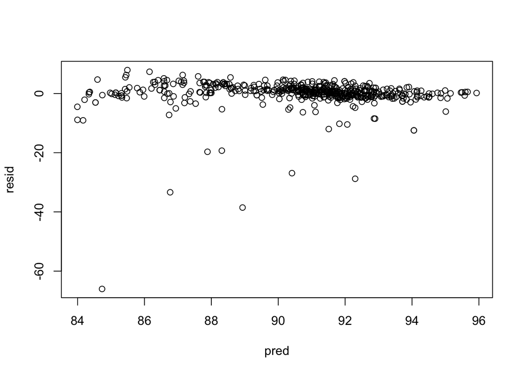

```r
ln_plot(response, covariates,type ="RF")
```

2. qq-plot of residuals

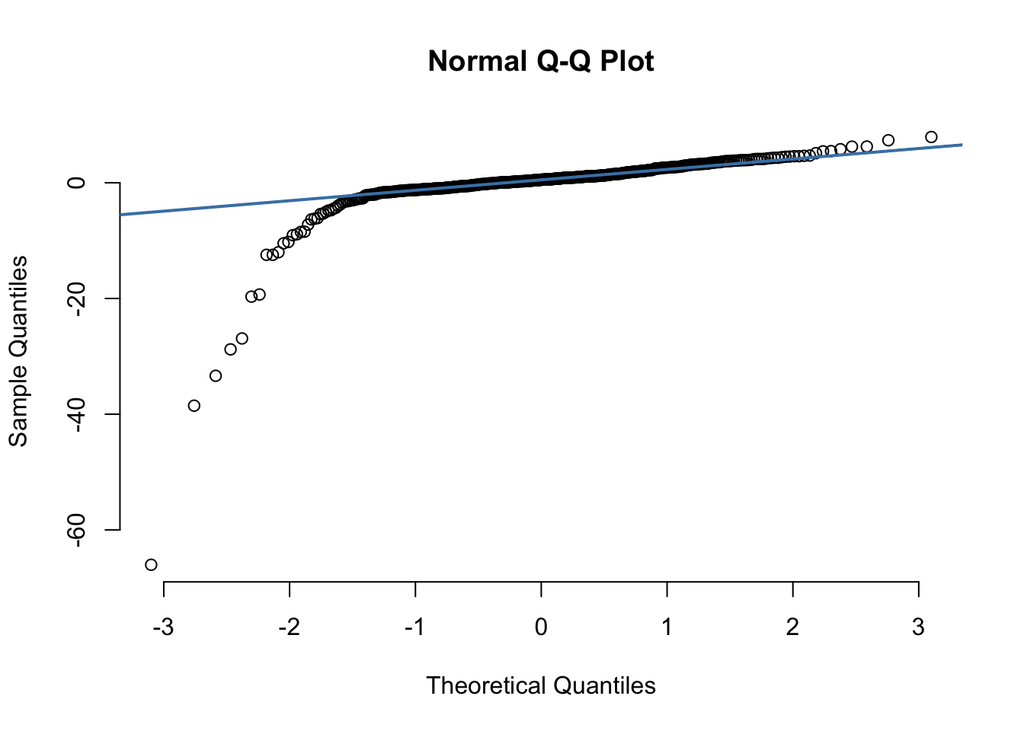

```r
ln_plot(response, covariates,type ="QQR")
```

3. Histogram (or density) of residuals

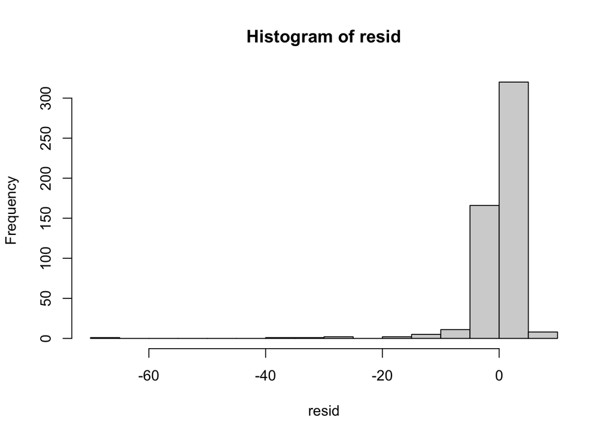

```r
ln_plot(response, covariates,type ="HR")
```

4. All three plots above

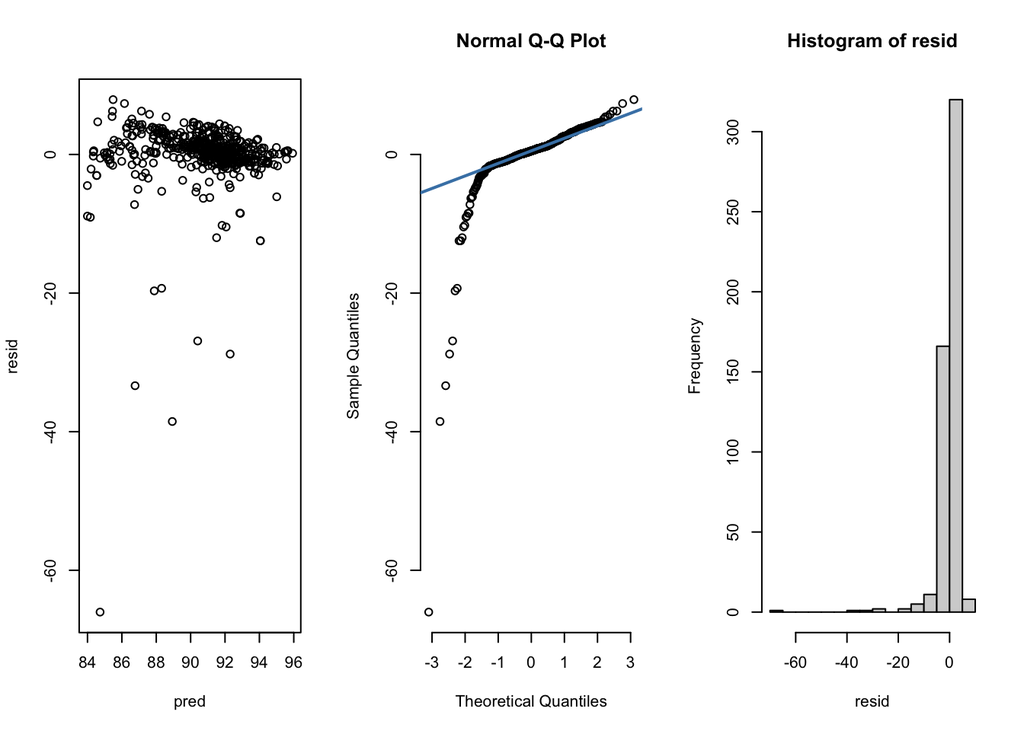

```r
ln_plot(response, covariates,type ="all")
```

### 3.Mean Square Prediction Error (MSPE):

The MSPE is a measure of a predictor’s fit. This function is used to calculate MSPE as follow.

```r
l_mspe(response, covariates)
```

```
## [1] 24.20274
```

### 4.F-test:

This function is used to conduct F-test as follow.

```r
l_ftest(response, covariates)
```

```
## [[1]]
## [1] 65.94111
##
## [[2]]
## [1] 3.221918e-26
```

In the output of R, the first value is F-Value(65.94) of the linear regreesion model. The second value (3.22e-26) is p-value for f-test. The outcome of f-test implies that these covariates (DC,temp) have a significant linear association with response(FFMC).